# Climate Change: A Comprehensive Review

By: Thomas Cruz, NDumo Smith, Papia Rahman

## Introduction

Climate change, once a controversial topic, is now considered a fact to most scientists and governments around the world. Climate change refers to the increase or decrease in temperature throughout different regions of the Earth as time passes. The data used for this review was obtained through the WorldBank and contained data on different climate change factors from the years 1990 - 2010. While the data set contains useful data on countries around the world this paper will primarily focus on the United States of America (USA) as other countries are missing some data entries. This paper aims at extracting meaningful climate information from noisy data in a more robust and reliable manner than before. In no way does this paper attempt to provide a solution for climate change, but rather, analyze and represent the data in more digestible ways for the reader.

## Import Required Packages

```python
import numpy as np
import pandas as pd
import matplotlib.pyplot as plt
from sklearn.linear_model import LinearRegression
from sklearn.model_selection import train_test_split
from sklearn.preprocessing import MinMaxScaler, StandardScaler
import scipy.stats as stats
import statsmodels.api as sm
from statsmodels.formula.api import ols
from __future__ import print_function
from __future__ import division
from scipy.sparse.linalg import svds as sparse_svd
from sklearn.decomposition import PCA
from sklearn.preprocessing import StandardScaler
from sklearn.datasets import load_boston,load_iris
import seaborn as sbn
import seaborn as sns
from sklearn.preprocessing import PolynomialFeatures
from  sklearn.linear_model import LassoCV
from numpy import where
import matplotlib.image as mpimg
from sklearn.cluster import KMeans
import sklearn
from sklearn.datasets import make_classification
from matplotlib import pyplot
from numpy import unique
from sklearn.cluster import AgglomerativeClustering
from sklearn.cluster import SpectralClustering
from sklearn.cluster import AffinityPropagation
from sklearn.cluster import Birch
from sklearn.cluster import MeanShift
from sklearn.cluster import OPTICS
%matplotlib inline
```

## Data Cleaning

The initial size of our data set was 13,512 x 28 and contained a lot of information that could not be used in this paper due to missing cells or irrelevance. We cleaned the data by converting all “..” cells to null cells then removing any rows containing null cells since all the data was not present. We then dropped several columns such as “Country Name”, “Series name”, “Scale”, “Decimals”, and “2011”. These columns were either redundant or did not have useful information. The next step we took was to filter the data relating to the USA since that is the country we will be focusing on during our experiments. We then took the transpose of the data set to have all the series codes as columns and corresponding years as rows. This will allow us to use the series codes as factors and the years 1990 – 2010 as the rows while conducting our experiments. The final step was to write a for loop that converted all of our columns from strings to float-64. This allows us to use each data entry as a numerical value rather than an object. The data set labeled definitions contains all the series codes, their names, and their definitions as a reference for this paper.

```python
#import data
data = pd.read_csv("climate_change (1).csv")
#clean data
df = pd.DataFrame(data)
print("This is the initial shape of the data set:", df.shape)
df[df.eq("..")] = np.nan
#df[df.eq("..")] = 0
df.drop("Country name", inplace=True, axis=1)
df.drop("Series name", inplace=True, axis=1)
df.drop("SCALE", inplace=True, axis=1)
df.drop("Decimals", inplace=True, axis=1)
df.drop("2011", inplace=True, axis=1)
df.rename(columns = {'Country code':'country', 'Series code':'series'}, inplace = True)
df = df.dropna(how='any',axis=0)
df = df[(df.country == 'USA')]
df.drop("country", inplace=True, axis=1)
df = pd.DataFrame.transpose(df)
df.columns = df.iloc[0]
df.rename(columns = {'series':'year'}, inplace = True)
df = df.drop(df.index[0])
for column in df:
    df[column] = df[column].astype(str).astype(float)
print("This is the shape of the data set after data cleaning:", df.shape)

df.info()
```

```
This is the initial shape of the data set: (13512, 28)
This is the shape of the data set after data cleaning: (21, 12)
<class 'pandas.core.frame.DataFrame'>
Index: 21 entries, 1990 to 2010
Data columns (total 12 columns):
 #   Column                Non-Null Count  Dtype
---  ------                --------------  -----
 0   BX.KLT.DINV.WD.GD.ZS  21 non-null     float64
 1   EG.USE.COMM.GD.PP.KD  21 non-null     float64
 2   EG.USE.PCAP.KG.OE     21 non-null     float64
 3   EN.CLC.MMDT.C         21 non-null     float64
 4   EN.URB.MCTY.TL.ZS     21 non-null     float64
 5   NY.GDP.MKTP.CD        21 non-null     float64
 6   NY.GNP.PCAP.CD        21 non-null     float64
 7   SH.DYN.MORT           21 non-null     float64
 8   SP.POP.GROW           21 non-null     float64
 9   SP.POP.TOTL           21 non-null     float64
 10  SP.URB.GROW           21 non-null     float64
 11  SP.URB.TOTL           21 non-null     float64
dtypes: float64(12)
memory usage: 2.1+ KB
```

```python
definitions = pd.read_csv("series.csv",encoding='cp1252')
print("The following data frame defines each series code:")
definitions
```

```
The following data frame defines each series code:
```

|  | Series code | Series name | Definition |
| --- | --- | --- | --- |
| 0 | AG.LND.EL5M.ZS | Land area below 5m (% of land area) | Land area below 5m is the percentage of total ... |
| 1 | AG.LND.IRIG.AG.ZS | Agricultural land under irrigation (% of total... | Agricultural irrigated land refers to agricult... |
| 2 | AG.YLD.CREL.KG | Cereal yield (kg per hectare) | Cereal yield, measured as kilograms per hectar... |
| 3 | BX.KLT.DINV.WD.GD.ZS | Foreign direct investment, net inflows (% of GDP) | Foreign direct investment, net inflows is inve... |
| 4 | EG.ELC.ACCS.ZS | Access to electricity (% of total population) | Access to electricity is the percentage of pop... |
| 5 | EG.USE.COMM.GD.PP.KD | Energy use per units of GDP (kg oil eq./$1,000... | Energy use per units of GDP is the kilogram of... |
| 6 | EG.USE.PCAP.KG.OE | Energy use per capita (kilograms of oil equiva... | Energy use per capita refers to use of primary... |
| 7 | EN.ATM.CO2E.KT | CO2 emissions, total (KtCO2) | Carbon dioxide emissions are those stemming fr... |
| 8 | EN.ATM.CO2E.PC | CO2 emissions per capita (metric tons) | Carbon dioxide (CO2) emissions per capita are ... |
| 9 | EN.ATM.CO2E.PP.GD.KD | CO2 emissions per units of GDP (kg/$1,000 of 2... | Carbon dioxide (CO2) emissions per units of GD... |
| 10 | EN.ATM.GHGO.KT.CE | Other GHG emissions, total (KtCO2e) | Other greenhouse gas emissions are byproduct e... |
| 11 | EN.ATM.METH.KT.CE | Methane (CH4) emissions, total (KtCO2e) | Methane emissions are emissions from human act... |
| 12 | EN.ATM.NOXE.KT.CE | Nitrous oxide (N2O) emissions, total (KtCO2e) | Nitrous oxide emissions are emissions from agr... |
| 13 | EN.CLC.AERT | Annex-I emissions reduction target | Annex-I emissions reduction target is the Anne... |
| 14 | EN.CLC.DRSK.XQ | Disaster risk reduction progress score (1-5 sc... | Disaster risk reduction progress score is an a... |
| 15 | EN.CLC.GHGR.MT.CE | GHG net emissions/removals by LUCF (MtCO2e) | GHG net emissions/removals by LUCF refers to c... |
| 16 | EN.CLC.HCDM | Hosted Clean Development Mechanism (CDM) projects | Hosted Clean Development Mechanism (CDM) proje... |
| 17 | EN.CLC.HJIP | Hosted Joint Implementation (JI) projects | Hosted Joint Implementation (JI) projects refe... |
| 18 | EN.CLC.HPPT.MM | Average annual precipitation (1961-1990, mm) | Average annual precipitation is the sum of the... |
| 19 | EN.CLC.ICER | Issued Certified Emission Reductions (CERs) fr... | Issued Certified Emission Reductions (CERs) fr... |
| 20 | EN.CLC.IERU | Issued Emission Reduction Units (ERUs) from JI... | Issued Emission Reduction Units (ERUs) from JI... |
| 21 | EN.CLC.MDAT.ZS | Droughts, floods, extreme temps (% pop. avg. 1... | Droughts, floods and extreme temperatures is t... |
| 22 | EN.CLC.MMDT.C | National annual average temperature | Average temperature in the country, averaged f... |
| 23 | EN.CLC.NAMA | NAMA submission | NAMA submission indicates whether a non-Annex-... |
| 24 | EN.CLC.NAPA | NAPA submission | NAPA submission indicates whether a country ha... |
| 25 | EN.CLC.NCOM | Latest UNFCCC national communication | Latest UNFCCC national communication is the da... |
| 26 | EN.CLC.PCAT.C | Projected annual temperature change (2045-2065... | Projected annual temperature change is the pro... |
| 27 | EN.CLC.PCCC | Projected change in annual cool days/cold nights | Projected change in annual cool days/cold nigh... |
| 28 | EN.CLC.PCHW | Projected change in annual hot days/warm nights | Projected change in annual hot days/warm night... |
| 29 | EN.CLC.PCPT.MM | Projected annual precipitation change (2045-20... | Projected annual precipitation change is the p... |
| 30 | EN.CLC.RNET | Renewable energy target | Renewable energy target indicates whether a co... |
| 31 | EN.POP.EL5M.ZS | Population below 5m (% of total) | Population below 5m is the percentage of the t... |
| 32 | EN.URB.MCTY.TL.ZS | Population in urban agglomerations >1million (%) | Population in urban agglomerations of more tha... |
| 33 | ER.H2O.FWTL.ZS | Annual freshwater withdrawals (% of internal r... | Annual freshwater withdrawal is total water wi... |
| 34 | ER.LND.PTLD.ZS | Nationally terrestrial protected areas (% of t... | Nationally terrestrial protected areas are tot... |
| 35 | IC.BUS.EASE.XQ | Ease of doing business (ranking 1-183; 1=best) | Ease of doing business ranks economies from 1 ... |
| 36 | IE.PPI.ENGY.CD | Invest. in energy w/ private participation ($) | Investment in energy with private participatio... |
| 37 | IE.PPI.TELE.CD | Invest. in telecoms w/ private participation ($) | Investment in telecoms with private participat... |
| 38 | IE.PPI.TRAN.CD | Invest. in transport w/ private participation ($) | Investment in transport with private participa... |
| 39 | IE.PPI.WATR.CD | Invest. in water/sanit. w/ private participati... | Investment in water and sanitation with privat... |
| 40 | IQ.CPA.PUBS.XQ | Public sector mgmt & institutions avg. (1-6 sc... | Public sector management & institutions averag... |
| 41 | IS.ROD.PAVE.ZS | Paved roads (% of total roads) | Paved roads are roads surfaced with crushed st... |
| 42 | NY.GDP.MKTP.CD | GDP ($) | GDP is gross domestic product and measures the... |
| 43 | NY.GNP.PCAP.CD | GNI per capita (Atlas $) | GNI per capita is the gross national income, c... |
| 44 | SE.ENR.PRSC.FM.ZS | Ratio of girls to boys in primary & secondary ... | Ratio of girls to boys in primary and secondar... |
| 45 | SE.PRM.CMPT.ZS | Primary completion rate, total (% of relevant ... | Primary completion rate is the percentage of s... |
| 46 | SH.DYN.MORT | Under-five mortality rate (per 1,000) | Under-five mortality rate is the probability p... |
| 47 | SH.H2O.SAFE.ZS | Access to improved water source (% of total pop.) | Access to improved water source is the percent... |
| 48 | SH.MED.NUMW.P3 | Nurses and midwives (per 1,000 people) | Nurses and midwives include professional nurse... |
| 49 | SH.MED.PHYS.ZS | Physicians (per 1,000 people) | Physicians include generalist and specialist m... |
| 50 | SH.MLR.INCD | Malaria incidence rate (per 100,000 people) | Malaria incidence rate is the number of new ca... |
| 51 | SH.STA.ACSN | Access to improved sanitation (% of total pop.) | Access to improved sanitation is the percentag... |
| 52 | SH.STA.MALN.ZS | Child malnutrition, underweight (% of under ag... | Child malnutrition, underweight is the percent... |
| 53 | SI.POV.DDAY | Population living below $1.25 a day (% of total) | Population living below $1.25 a day is the per... |
| 54 | SP.POP.GROW | Population growth (annual %) | Annual population growth rate for year t is th... |
| 55 | SP.POP.TOTL | Population | Population includes all residents who are pres... |
| 56 | SP.URB.GROW | Urban population growth (annual %) | Annual urban population growth rate for year t... |
| 57 | SP.URB.TOTL | Urban population | Urban population is the share of the midyear p... |

## Normality

In order to validate our results from each experiment we must first confirm two assumptions. The first assumption is independence. This assumption means that all groups are mutually exclusive. This is validated through the “definitions” data set where we can see that each series code represents different data throughout the years.

The second assumption is Normality. We test for Normality in this section through the Shapiro-Wilk test: shapiro() method from scipy.stats. After running this test the result is presented as (W-test statistic, p-value).

The test is non-significant, W= 0.9444396495819092, p=0.2663561701774597, which indicates that the residuals are normally distributed. We also visually confirmed normality through a probability plot of the models residuals.

```
ShapiroResult(statistic=0.9444396495819092, pvalue=0.2663561701774597)
```

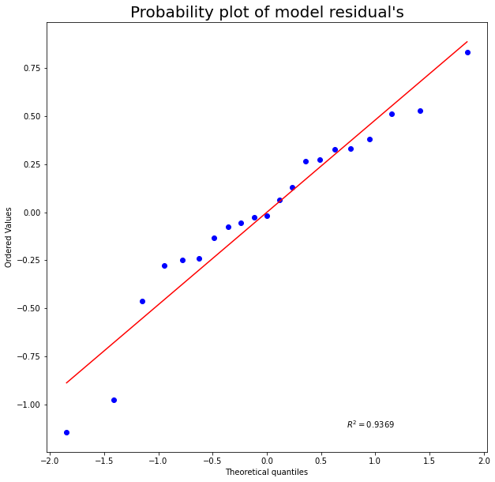

```python
X = df[["BX.KLT.DINV.WD.GD.ZS","EG.USE.COMM.GD.PP.KD","EG.USE.PCAP.KG.OE","EN.URB.MCTY.TL.ZS","NY.GDP.MKTP.CD","NY.GNP.PCAP.CD","SH.DYN.MORT","SP.POP.GROW","SP.POP.TOTL","SP.URB.GROW","SP.URB.TOTL"]]
y = df["EN.CLC.MMDT.C"]
model = ols('y ~ X', data=df).fit()
print(stats.shapiro(model.resid))

fig = plt.figure(figsize= (10, 10))
ax = fig.add_subplot(111)

normality_plot, stat = stats.probplot(model.resid, plot= plt, rvalue= True)
ax.set_title("Probability plot of model residual's", fontsize= 20)
ax.set

plt.show()
```

## ANOVA

```python
X = df[["BX.KLT.DINV.WD.GD.ZS","EG.USE.COMM.GD.PP.KD","EG.USE.PCAP.KG.OE","EN.URB.MCTY.TL.ZS","NY.GDP.MKTP.CD","NY.GNP.PCAP.CD","SH.DYN.MORT","SP.POP.GROW","SP.POP.TOTL","SP.URB.GROW","SP.URB.TOTL"]]
y = df["EN.CLC.MMDT.C"]
model = ols('y ~ X', data=df).fit()
aov_table = sm.stats.anova_lm(model, typ=2)
aov_table
```

```
C:\Users\User 1\anaconda3\lib\site-packages\statsmodels\base\model.py:1832: ValueWarning: covariance of constraints does not have full rank. The number of constraints is 11, but rank is 8
  warnings.warn('covariance of constraints does not have full '
```

|  | sum_sq | df | F | PR(>F) |
| --- | --- | --- | --- | --- |
| X | 6.938858 | 11.0 | 1.557583 | 0.242975 |
| Residual | 4.454888 | 11.0 | NaN | NaN |

## Correlation

[output not shown]

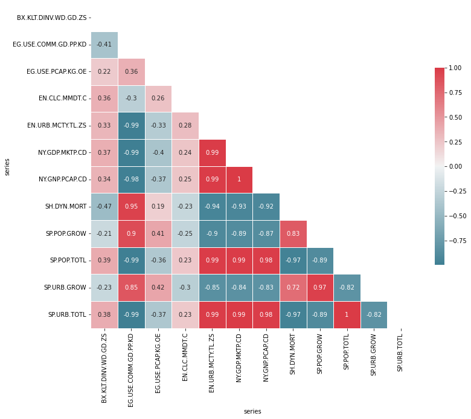

```python
RE_corr = df.corr()
corr =RE_corr.values
# Correlation between features

mask = np.zeros_like(corr, dtype=np.bool)
mask[np.triu_indices_from(mask)] = True

# Set up the matplotlib figure
f, ax = plt.subplots(figsize=(12, 12))

# Generate a custom diverging colormap
cmap = sbn.diverging_palette(220, 10, as_cmap=True)

# Draw the heatmap with the mask and correct aspect ratio
sbn.heatmap(RE_corr, mask=mask, cmap=cmap, vmax=1.0,annot=True, center=0,
            square=True, linewidths=.5, cbar_kws={"shrink": .5})

print("Highest Correlation between X4 and Y showing that the prices mostly depends on how many convenience stores near by.")
```

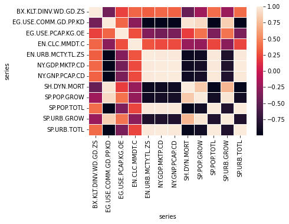

```python
ax = sns.heatmap(df.corr(), linewidths=.5)
```

```python
data_mat = df.values
X = data_mat[:,0:7]
Y = data_mat[:,7]
np.set_printoptions(precision=2, suppress=True)
sigmaX = np.std(X,axis=0)
# X = X/sigmaX # If Correlation PCA is required
muX = np.mean(X, axis=0)
n = X.shape[0]
print("The size of data set is:", n)
S = np.dot((X - muX).T, (X - muX)) / (n-1)
print('Covariance matrix: \n:')
print(S)
```

```
The size of data set is: 21
Covariance matrix:
:
[[ 6.44e-01 -8.27e+00  3.91e+01  2.19e-01  3.04e-01  8.83e+11  2.40e+03]
 [-8.27e+00  6.45e+02  2.05e+03 -5.75e+00 -2.90e+01 -7.57e+13 -2.17e+05]
 [ 3.91e+01  2.05e+03  5.12e+04  4.55e+01 -8.58e+01 -2.71e+14 -7.26e+05]
 [ 2.19e-01 -5.75e+00  4.55e+01  5.85e-01  2.50e-01  5.63e+11  1.64e+03]
 [ 3.04e-01 -2.90e+01 -8.58e+01  2.50e-01  1.33e+00  3.44e+12  9.93e+03]
 [ 8.83e+11 -7.57e+13 -2.71e+14  5.63e+11  3.44e+12  9.05e+24  2.61e+16]
 [ 2.40e+03 -2.17e+05 -7.26e+05  1.64e+03  9.93e+03  2.61e+16  7.57e+07]]
```

```python
# Eigenvalue Decomposition of S
w, v = np.linalg.eig(S)

#print('Eigenvectors \n%s' %v)
print('\nEigenvalues \n%s' %w)
print('\n Explained Ratio: \n%s' %(w/np.sum(w)))
```

```
Eigenvalues
[0.00e+00 9.05e+24 6.24e+05 3.78e+04 8.10e+00 1.14e-02 4.05e-01]

 Explained Ratio:
[0. 1. 0. 0. 0. 0. 0.]
```

```python
#SVD based approach
muX = np.mean(X, axis=0)
n = X.shape[0]
print("The size of data set is:", n)
U,s,V = np.linalg.svd(X-muX)
#print('Covariance matrix: \n:')
#print(S)
s2 = s**2;
print('\n Singularvalues \n%s' %s)
print('\n Singularvalues *(n-1) \n {}'.format(s**2/(n-1)))
print('\n Explained Ratio: \n%s' %(s2/np.sum(s2)))
```

```
The size of data set is: 21

 Singularvalues
[1.35e+13 3.53e+03 8.70e+02 1.27e+01 2.93e+00 2.64e+00 2.55e-01]

 Singularvalues *(n-1)
 [9.05e+24 6.24e+05 3.78e+04 8.08e+00 4.30e-01 3.50e-01 3.25e-03]

 Explained Ratio:
[1. 0. 0. 0. 0. 0. 0.]
```

```python
# Instantiate PCA
pca = PCA(n_components=3)
pca.fit((X-muX).T) # Features are the rows in Standard PCA by convention, so we transform

Xpca = pca.transform(X.T)
#print("PCA components: %s") # pca.explained_variance_
#print(pca.components_)
print ("Explained Variance Ratio")
print (pca.explained_variance_ratio_)
```

```
Explained Variance Ratio
[1. 0. 0.]
```

```python
# Instantiate PCA
pca = PCA(n_components=7)
muX = np.mean(X, axis=0)
sigmaX = np.std(X,axis=0)
Xn = (X-muX)/sigmaX # One can use the StandardScalar available with ScikitLearn
pca.fit(Xn.T) # Features are the rows, so we transform

Xpca = pca.transform(Xn.T)

print("PCA components:", Xpca) # pca.explained_variance_
#print(pca.components_)
print ("Explained Variance Ratio")
print (pca.explained_variance_ratio_)
```

```
PCA components: [[-0.08 -2.   -2.54 -1.16  0.02 -0.01 -0.  ]
 [ 5.66  2.4   0.04 -1.06  0.01 -0.01  0.  ]
 [ 3.74 -1.02 -0.28  2.34 -0.02  0.01  0.  ]
 [ 0.45 -2.14  2.62 -0.9  -0.01  0.    0.  ]
 [-3.22  0.84  0.22  0.46  0.29 -0.07  0.  ]
 [-3.3   0.94 -0.06  0.05 -0.02  0.16  0.  ]
 [-3.26  0.97  0.02  0.25 -0.27 -0.09  0.  ]]
Explained Variance Ratio
[0.66 0.15 0.11 0.08 0.   0.   0.  ]
```

```python
X_RE = StandardScaler().fit_transform(df)
pca_RE = PCA(n_components=7)
pc_RE = pca_RE.fit_transform(X_RE)
pca_RE.explained_variance_ratio_
```

```
array([0.73, 0.13, 0.06, 0.04, 0.02, 0.01, 0.  ])
```

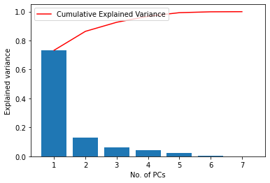

```python
# There is somethign wrong here. Needs correction
plt.bar(range(1,len(pca_RE.explained_variance_ratio_ )+1),pca_RE.explained_variance_ratio_ )
plt.ylabel('Explained variance')
plt.xlabel('No. of PCs')
plt.plot(range(1,len(pca_RE.explained_variance_ratio_ )+1),
         np.cumsum(pca_RE.explained_variance_ratio_),
         c='red',
         label="Cumulative Explained Variance")
plt.legend(loc='upper left')
```

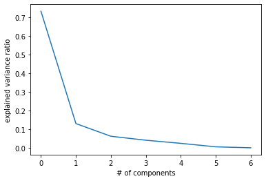

```
As # of components increase, variance ratio decreases
```

```python
# Scree-plot: #comp vs eigenvalue
plt.plot(pca_RE.explained_variance_ratio_)
plt.xlabel('# of components')
plt.ylabel('explained variance ratio')
plt.show()

print("As # of components increase, variance ratio decreases")
```

```
clusters most between -2 & 2
```

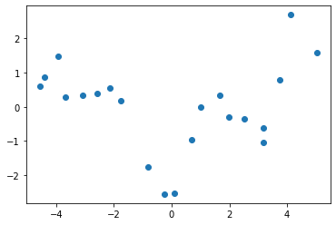

```python
plt.scatter(pc_RE[:, 0], pc_RE[:, 1])
print("clusters most between -2 & 2")
```

## Linear Regression

```python
X = df[["BX.KLT.DINV.WD.GD.ZS","EG.USE.COMM.GD.PP.KD","EG.USE.PCAP.KG.OE","EN.URB.MCTY.TL.ZS","NY.GDP.MKTP.CD","NY.GNP.PCAP.CD","SH.DYN.MORT","SP.POP.GROW","SP.POP.TOTL","SP.URB.GROW","SP.URB.TOTL"]]
y = df["EN.CLC.MMDT.C"]
X_train, X_test, y_train, y_test  = train_test_split(X, y, test_size=0.3, random_state=100)
normalizer = MinMaxScaler()
normalizer.fit(X_train)
X_train_n = normalizer.transform(X_train) # Is built on training data
X_test_n = normalizer.transform(X_test) # Same normalizer used for test dataa too
# Create a Linear Regression Model
linreg = LinearRegression()
# TRAIN THE MODEL
linreg.fit(X_train_n, y_train)
y_test_pred = linreg.predict(X_test_n)
print (y_test_pred[:])
print( y_test[:])
```

```
[61.35 76.16 54.15 74.19 53.7  50.08 52.25]
2008    52.29
2010    52.98
2001    53.69
2009    52.39
2003    53.26
1996    51.88
1990    53.51
Name: EN.CLC.MMDT.C, dtype: float64
```

```python
# R^2 : Coefficient of determination. Goodness of fit
print (linreg.score(X_train_n, y_train))
print (linreg.score(X_test_n, y_test))
```

```
0.998290248479228
-392.9870386158733
```

```python
# Create an object of  The Polynomial Feature class
poly = PolynomialFeatures(degree=2, include_bias=False)
Xp = poly.fit_transform(X)
print (Xp[0])
```

```
[8.40e-01 2.40e+02 7.67e+03 4.16e+01 5.75e+12 2.33e+04 1.13e+01 1.13e+00
 2.50e+08 1.34e+00 1.88e+08 7.06e-01 2.02e+02 6.44e+03 3.49e+01 4.83e+12
 1.95e+04 9.49e+00 9.49e-01 2.10e+08 1.13e+00 1.58e+08 5.77e+04 1.84e+06
 9.99e+03 1.38e+15 5.59e+06 2.72e+03 2.72e+02 6.00e+10 3.22e+02 4.52e+10
 5.89e+07 3.19e+05 4.41e+16 1.78e+08 8.67e+04 8.67e+03 1.91e+12 1.03e+04
 1.44e+12 1.73e+03 2.39e+14 9.67e+05 4.70e+02 4.70e+01 1.04e+10 5.57e+01
 7.81e+09 3.31e+25 1.34e+17 6.50e+13 6.50e+12 1.44e+21 7.71e+12 1.08e+21
 5.41e+08 2.63e+05 2.63e+04 5.81e+12 3.12e+04 4.37e+12 1.28e+02 1.28e+01
 2.82e+09 1.51e+01 2.12e+09 1.28e+00 2.82e+08 1.51e+00 2.12e+08 6.23e+16
 3.34e+08 4.69e+16 1.80e+00 2.52e+08 3.53e+16]
```

```python
# Split Data into Train and Test subsets
Xp_train, Xp_test, y_train, y_test  = train_test_split(Xp, y, test_size=0.25, random_state=10)

# Preprocess: Normalize the Features
normalizer = MinMaxScaler()
normalizer.fit(Xp_train)
Xpn_train = normalizer.transform(Xp_train) # Is built on training data
Xpn_test = normalizer.transform(Xp_test) # Same normalizer used for test dataa too

# Create a Linear Regression Model
linreg = LassoCV(alphas=[  0.01, 0.05, 1.0, 5, 10, 100], max_iter=100, tol=0.00001)
#linreg = linear_model.RidgeCV(alphas=[0.001, 0.01, 0.05, 1.0, 5, 10, 100])
# TRAIN THE MODEL
#linreg = linear_model.LinearRegression()
linreg.fit(Xpn_train, y_train)
```

[output not shown]

```
LassoCV(alphas=[0.01, 0.05, 1.0, 5, 10, 100], max_iter=100, tol=1e-05)
```

```python
# R^2 : Coefficient of determination. Goodness of fit
print(linreg.score(Xpn_train, y_train))
print (linreg.score(Xpn_test, y_test))
```

```
0.6357464457632779
-0.35465981136871694
```

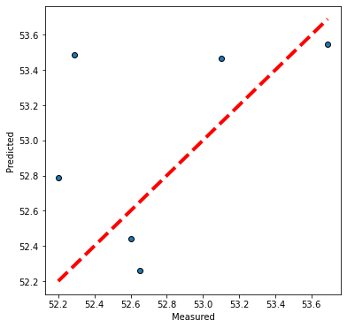

```python
y_pred = linreg.predict(Xpn_test)
fig, ax = plt.subplots()
fig.set_size_inches(6,6)
ax.scatter(y_test, y_pred, edgecolors=(0, 0, 0))
ax.plot([y_test.min(), y_test.max()], [y_test.min(), y_test.max()], 'r--', lw=4)
ax.set_xlabel('Measured')
ax.set_ylabel('Predicted')
plt.show()
```

## Clustering

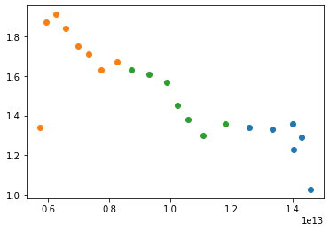

```
The cluster centers are:
[[1.54e+00 1.75e+02 7.51e+03 5.32e+01 4.46e+01 1.38e+13 4.65e+04 7.75e+00
  8.87e-01 3.03e+08 1.26e+00 2.47e+08]
 [7.72e-01 2.33e+02 7.74e+03 5.25e+01 4.20e+01 6.86e+12 2.64e+04 1.00e+01
  1.25e+00 2.61e+08 1.72e+00 2.00e+08]
 [1.81e+00 1.99e+02 7.87e+03 5.35e+01 4.34e+01 1.02e+13 3.57e+04 8.41e+00
  1.03e+00 2.85e+08 1.47e+00 2.26e+08]]
```

```python
#k-means clustering
X = np.array(df)
#define the model
model = KMeans(n_clusters=3)
#fit the model
model.fit(X)
#assign a cluster to each example
yhat = model.predict(X)
#retrieve unique clusters
clusters = unique(yhat)
#create scatter plot for samples from each cluster
for cluster in clusters:
	# get row indexes for samples with this cluster
	row_ix = where(yhat == cluster)
	# create scatter of these samples
	pyplot.scatter(X[row_ix, 5], X[row_ix, 10])
#show the plot
pyplot.show()
print ("The cluster centers are:")
cs = np.round( model.cluster_centers_, 3)
print (cs)
```

```
C:\Users\User 1\anaconda3\lib\site-packages\sklearn\manifold\_spectral_embedding.py:245: UserWarning: Graph is not fully connected, spectral embedding may not work as expected.
  warnings.warn("Graph is not fully connected, spectral embedding"
```

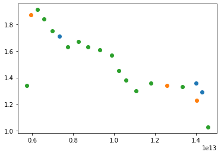

```python
#Spectral Clustering
# define the model
X = np.array(df)
model = SpectralClustering(n_clusters=3)
# fit model and predict clusters
yhat = model.fit_predict(X)
# retrieve unique clusters
clusters = unique(yhat)
# create scatter plot for samples from each cluster
for cluster in clusters:
	# get row indexes for samples with this cluster
	row_ix = where(yhat == cluster)
	# create scatter of these samples
	pyplot.scatter(X[row_ix, 5], X[row_ix, 10])
# show the plot
pyplot.show()
```

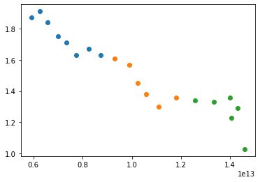

```python
# agglomerative clustering
# define dataset
X = np.array(df)
X = (X[1:300])
# define the model
model = AgglomerativeClustering(n_clusters=3)
# fit model and predict clusters
yhat = model.fit_predict(X)
# retrieve unique clusters
clusters = unique(yhat)
# create scatter plot for samples from each cluster
for cluster in clusters:
	# get row indexes for samples with this cluster
	row_ix = where(yhat == cluster)
	# create scatter of these samples
	pyplot.scatter(X[row_ix, 5], X[row_ix, 10])
# show the plot
pyplot.show()
```

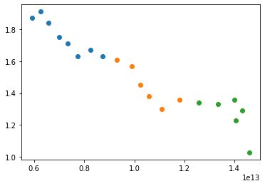

```python
# birch clustering
# define dataset
X = np.array(df)
X = (X[1:300])
# define the model
model = Birch(threshold=0.01, n_clusters=3)
# fit the model
model.fit(X)
# assign a cluster to each example
yhat = model.predict(X)
# retrieve unique clusters
clusters = unique(yhat)
# create scatter plot for samples from each cluster
for cluster in clusters:
	# get row indexes for samples with this cluster
	row_ix = where(yhat == cluster)
	# create scatter of these samples
	pyplot.scatter(X[row_ix, 5], X[row_ix, 10])
# show the plot
pyplot.show()
```

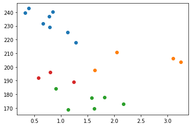

```python
# mean shift clustering

# define dataset
X = np.array(df)
# define the model
model = MeanShift()
# fit model and predict clusters
yhat = model.fit_predict(X)
# retrieve unique clusters
clusters = unique(yhat)
# create scatter plot for samples from each cluster
for cluster in clusters:
	# get row indexes for samples with this cluster
	row_ix = where(yhat == cluster)
	# create scatter of these samples
	pyplot.scatter(X[row_ix, 0], X[row_ix, 1])
# show the plot
pyplot.show()
```

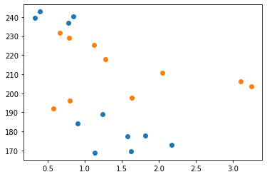

```python
# optics clustering
# define dataset
X = np.array(df)
# define the model
model = OPTICS(eps=0.8, min_samples=10)
# fit model and predict clusters
yhat = model.fit_predict(X)
# retrieve unique clusters
clusters = unique(yhat)
# create scatter plot for samples from each cluster
for cluster in clusters:
	# get row indexes for samples with this cluster
	row_ix = where(yhat == cluster)
	# create scatter of these samples
	pyplot.scatter(X[row_ix, 0], X[row_ix, 1])
# show the plot
pyplot.show()
```